## title: "R Notebook" output: html_document: df_print: paged pdf_document: default editor_options: markdown: wrap: 72

# importing dataset

```r
dataset = read.csv('BreastCancer1.csv')
str(dataset)
library(Hmisc)
describe(dataset)
summary(dataset)
```

```
'data.frame':	4024 obs. of  16 variables:
 $ Age                   : int  68 50 58 58 47 51 51 40 40 69 ...
 $ Race                  : chr  "White" "White" "White" "White" ...
 $ Marital.Status        : chr  "Married" "Married" "Divorced" "Married" ...
 $ T.Stage               : chr  "T1" "T2" "T3" "T1" ...
 $ N.Stage               : chr  "N1" "N2" "N3" "N1" ...
 $ X6th.Stage            : chr  "IIA" "IIIA" "IIIC" "IIA" ...
 $ differentiate         : chr  "Poorly differentiated" "Moderately differentiated" "Moderately differentiated" "Poorly differentiated" ...
 $ Grade                 : chr  "3" "2" "2" "3" ...
 $ A.Stage               : chr  "Regional" "Regional" "Regional" "Regional" ...
 $ Tumor.Size            : int  4 35 63 18 41 20 8 30 103 32 ...
 $ Estrogen.Status       : chr  "Positive" "Positive" "Positive" "Positive" ...
 $ Progesterone.Status   : chr  "Positive" "Positive" "Positive" "Positive" ...
 $ Regional.Node.Examined: int  24 14 14 2 3 18 11 9 20 21 ...
 $ Reginol.Node.Positive : int  1 5 7 1 1 2 1 1 18 12 ...
 $ Survival.Months       : int  60 62 75 84 50 89 54 14 70 92 ...
 $ Status                : chr  "Alive" "Alive" "Alive" "Alive" ...
```

```
dataset

 16  Variables      4024  Observations
--------------------------------------------------------------------------------
Age
       n  missing distinct     Info     Mean      Gmd      .05      .10
    4024        0       40    0.999    53.97    10.27       39       42
     .25      .50      .75      .90      .95
      47       54       61       66       68

lowest : 30 31 32 33 34, highest: 65 66 67 68 69
--------------------------------------------------------------------------------
Race
       n  missing distinct
    4024        0        3

Value      Black Other White
Frequency    291   320  3413
Proportion 0.072 0.080 0.848
--------------------------------------------------------------------------------
Marital.Status
       n  missing distinct
    4024        0        5

Value       Divorced   Married Separated    Single   Widowed
Frequency        486      2643        45       615       235
Proportion     0.121     0.657     0.011     0.153     0.058
--------------------------------------------------------------------------------
T.Stage
       n  missing distinct
    4024        0        4

Value         T1    T2    T3    T4
Frequency   1603  1786   533   102
Proportion 0.398 0.444 0.132 0.025
--------------------------------------------------------------------------------
N.Stage
       n  missing distinct
    4024        0        3

```

[output cut: 85 more lines]

```
       n  missing distinct     Info     Mean      Gmd      .05      .10
    4024        0      107        1     71.3    25.74    26.15    44.00
     .25      .50      .75      .90      .95
   56.00    73.00    90.00   100.00   103.00

lowest :   1   2   3   4   5, highest: 103 104 105 106 107
--------------------------------------------------------------------------------
Status
       n  missing distinct
    4024        0        2

Value      Alive  Dead
Frequency   3408   616
Proportion 0.847 0.153
--------------------------------------------------------------------------------
```

```
      Age            Race           Marital.Status       T.Stage
 Min.   :30.00   Length:4024        Length:4024        Length:4024
 1st Qu.:47.00   Class :character   Class :character   Class :character
 Median :54.00   Mode  :character   Mode  :character   Mode  :character
 Mean   :53.97
 3rd Qu.:61.00
 Max.   :69.00
   N.Stage           X6th.Stage        differentiate         Grade
 Length:4024        Length:4024        Length:4024        Length:4024
 Class :character   Class :character   Class :character   Class :character
 Mode  :character   Mode  :character   Mode  :character   Mode  :character



   A.Stage            Tumor.Size     Estrogen.Status    Progesterone.Status
 Length:4024        Min.   :  1.00   Length:4024        Length:4024
 Class :character   1st Qu.: 16.00   Class :character   Class :character
 Mode  :character   Median : 25.00   Mode  :character   Mode  :character
                    Mean   : 30.47
                    3rd Qu.: 38.00
                    Max.   :140.00
 Regional.Node.Examined Reginol.Node.Positive Survival.Months
 Min.   : 1.00          Min.   : 1.000        Min.   :  1.0
 1st Qu.: 9.00          1st Qu.: 1.000        1st Qu.: 56.0
 Median :14.00          Median : 2.000        Median : 73.0
 Mean   :14.36          Mean   : 4.158        Mean   : 71.3
 3rd Qu.:19.00          3rd Qu.: 5.000        3rd Qu.: 90.0
 Max.   :61.00          Max.   :46.000        Max.   :107.0
    Status
 Length:4024
 Class :character
 Mode  :character
```

# problem

Breast cancer, a leading cause of global cancer-related deaths, presents a challenge in tailoring treatments due to its heterogeneity in nature, but homogeneity in treatment due to the fact that the current treatment landscape often lacks personalized approaches, primarily because of a limited emphasis on prognosis assessment. This oversight becomes glaringly evident in the observed survival rate disparities, such as the approximate 90% survival rate for caucasian women compared to the 80% rate for African American women. By focusing on prognosis, we aim to bridge the gap in treatment personalization and resource allocation. This is not merely a statistical concern but a pressing matter of healthcare equity and the optimal utilization of resources. The goal of this project is to develop a machine learning model that goes beyond traditional diagnostic approaches and provides a nuanced understanding of individual patient prognosis. By identifying factors contributing to higher risk of death, we aspire to enhance treatment personalization, ensuring that resources are allocated more efficiently to patients who are at a greater risk. This approach not only addresses the disparities in survival rates among different demographic groups but also contributes to a more equitable and effective breast cancer treatment landscape on a global scale.

# Data Mining Task :

# Data Mining Tasks: Classification and Clustering

This project involves two primary data mining tasks: classification and clustering, each contributing to the overarching goal of helping healthcare professionals to make informed decision, and enhancing treatment plans, improved counseling, and resource allocation towards patients who have a higher risk of death.

# 1. Classification:

Class Attribute: The class attribute for the classification task is the "patient status," which is binary and categorized as either "alive" or "dead."

Goal: The classification model can be used to predict whether a patient's status will be "alive" or dead". This will serve as a valuable tool for healthcare professionals to make informed decision regarding patient careuch as early intervention strategies , since these predictions can be used to identify risk factors for breast cancer death, which could result in developing more optimized strategies and treatments.

# 2. Clustering:

Goal: the clustering task aims to uncover patterns and subgroups within the patient population based on shared characteristics Utilizing clinical data such as T-Stage, age, and N-Stage. This enables a more nuanced understanding of the heterogeneity of breast cancer, facilitating the identification of specific patient profiles that may have similar prognostic implications.

# Data:

The source of the dataset: obtained from the 2017 November update of the SEER Program of the NCI, from kaggle website, URL: https://www.kaggle.com/datasets/reihanenamdari/breast-cancer

# Dataset Description:

# General Information

- Number of attributes : 16
- Number of objects : 4024
- The class name : status.

```r
#Number of rows
nrow(dataset)
#Number of columns
ncol(dataset)
```

4024

16

- Types of attribute :

| Attribute name | Description | Data type | Possible values |
| --- | --- | --- | --- |
| Age | Age of the patients | numeric | between 30 - 70 |
| Race | Classification of people based on their physical characteristics such as skin color | nominal | white, black or other |
| Marital status | Refers to whether the patient is married, single, or divorced etc | nominal | Divorced, Married, Separated, Single, Widowed |
| T stage | Describe the tumor's size and if it has spread | ordinal | T1, T2, T3, T4 |
| N stage | Indicates whether the cancer has spread to lymph nodes near the breast | ordinal | N1, N2, N3 |
| 6th stage | Describes invasive breast cancer | Ordinal | IIA, IIB, IIIA, IIIB, IIIC |
| Differentiation | Describes how well developed the tumor cells are and how cancer cells are organized in the tumor tissue | ordinal | Moderately differentiated, Poorly differentiated, Undifferentiated, Well differentiated |
| Grade | Depends on what the cells look like, lower grade indicates slower-growing cancer unlike higher grades | ordinal | 1, 2, 3, 4 |
| A stage | Regional: neoplasm that has extended; Distant: neoplasm that has spread to parts of the body remote from | asymmetric binary | Regional, Distant |
| Tumor size | Each indicates exact size of the tumor in millimeters | ordinal | from 1 to 140 |
| Estrogen status | The cancer is estrogen receptor-positive if it has receptors for estrogen | asymmetric binary | Negative, Positive |
| Progesterone status | The cancer is progesterone receptor-positive if it has progesterone receptors | asymmetric binary | Negative, Positive |
| Regional Node Examined | The number of the regional node that have been examined | numeric | from 1 to 61 |
| Regional Node Positive | The number of the regional node confirmed to have cancer | numeric | from 1 to 46 |
| Survival Months | It predicts the number of months to live based on the patient's state | numeric | from 1 to 107 |
| Status | Describes whether the patient is dead or alive | asymmetric binary | Dead, Alive |

# Moving forward, we applied some statistical measures on the dataset to better understand them. The following code show the process:

# statistical summaries

```r
summary(dataset)
var(dataset)
var(dataset$Tumor.Size)
var(dataset$Regional.Node.Examined)
var(dataset$Reginol.Node.Positive)
var(dataset$Survival.Months)
var(dataset$Age)
```

```
      Age            Race           Marital.Status       T.Stage
 Min.   :30.00   Length:4024        Length:4024        Length:4024
 1st Qu.:47.00   Class :character   Class :character   Class :character
 Median :54.00   Mode  :character   Mode  :character   Mode  :character
 Mean   :53.97
 3rd Qu.:61.00
 Max.   :69.00
   N.Stage           X6th.Stage        differentiate         Grade
 Length:4024        Length:4024        Length:4024        Length:4024
 Class :character   Class :character   Class :character   Class :character
 Mode  :character   Mode  :character   Mode  :character   Mode  :character



   A.Stage            Tumor.Size     Estrogen.Status    Progesterone.Status
 Length:4024        Min.   :  1.00   Length:4024        Length:4024
 Class :character   1st Qu.: 16.00   Class :character   Class :character
 Mode  :character   Median : 25.00   Mode  :character   Mode  :character
                    Mean   : 30.47
                    3rd Qu.: 38.00
                    Max.   :140.00
 Regional.Node.Examined Reginol.Node.Positive Survival.Months
 Min.   : 1.00          Min.   : 1.000        Min.   :  1.0
 1st Qu.: 9.00          1st Qu.: 1.000        1st Qu.: 56.0
 Median :14.00          Median : 2.000        Median : 73.0
 Mean   :14.36          Mean   : 4.158        Mean   : 71.3
 3rd Qu.:19.00          3rd Qu.: 5.000        3rd Qu.: 90.0
 Max.   :61.00          Max.   :46.000        Max.   :107.0
    Status
 Length:4024
 Class :character
 Mode  :character
```

A matrix: 16 × 16 of type dbl

|  | Age | Race | Marital.Status | T.Stage | N.Stage | X6th.Stage | differentiate | Grade | A.Stage | Tumor.Size | Estrogen.Status | Progesterone.Status | Regional.Node.Examined | Reginol.Node.Positive | Survival.Months | Status |
| --- | --- | --- | --- | --- | --- | --- | --- | --- | --- | --- | --- | --- | --- | --- | --- | --- |
| Age | 80.3377784 | NA | NA | NA | NA | NA | NA | NA | NA | -14.61669 | NA | NA | -2.420831 | 0.5763614 | -1.929065 | NA |
| Race | NA | NA | NA | NA | NA | NA | NA | NA | NA | NA | NA | NA | NA | NA | NA | NA |
| Marital.Status | NA | NA | NA | NA | NA | NA | NA | NA | NA | NA | NA | NA | NA | NA | NA | NA |
| T.Stage | NA | NA | NA | NA | NA | NA | NA | NA | NA | NA | NA | NA | NA | NA | NA | NA |
| N.Stage | NA | NA | NA | NA | NA | NA | NA | NA | NA | NA | NA | NA | NA | NA | NA | NA |
| X6th.Stage | NA | NA | NA | NA | NA | NA | NA | NA | NA | NA | NA | NA | NA | NA | NA | NA |
| differentiate | NA | NA | NA | NA | NA | NA | NA | NA | NA | NA | NA | NA | NA | NA | NA | NA |
| Grade | NA | NA | NA | NA | NA | NA | NA | NA | NA | NA | NA | NA | NA | NA | NA | NA |
| A.Stage | NA | NA | NA | NA | NA | NA | NA | NA | NA | NA | NA | NA | NA | NA | NA | NA |
| Tumor.Size | -14.6166916 | NA | NA | NA | NA | NA | NA | NA | NA | 446.04156 | NA | NA | 17.850697 | 26.1483354 | -42.068336 | NA |
| Estrogen.Status | NA | NA | NA | NA | NA | NA | NA | NA | NA | NA | NA | NA | NA | NA | NA | NA |
| Progesterone.Status | NA | NA | NA | NA | NA | NA | NA | NA | NA | NA | NA | NA | NA | NA | NA | NA |
| Regional.Node.Examined | -2.4208312 | NA | NA | NA | NA | NA | NA | NA | NA | 17.85070 | NA | NA | 65.604732 | 17.0327814 | -4.094500 | NA |
| Reginol.Node.Positive | 0.5763614 | NA | NA | NA | NA | NA | NA | NA | NA | 26.14834 | NA | NA | 17.032781 | 26.1052645 | -15.835323 | NA |
| Survival.Months | -1.9290649 | NA | NA | NA | NA | NA | NA | NA | NA | -42.06834 | NA | NA | -4.094500 | -15.8353229 | 525.391932 | NA |
| Status | NA | NA | NA | NA | NA | NA | NA | NA | NA | NA | NA | NA | NA | NA | NA | NA |

446.041562951399

65.6047319735576

26.1052645103775

525.391932212344

80.3377784498577

# here we have a graphic display of the five-number summary and the outliers

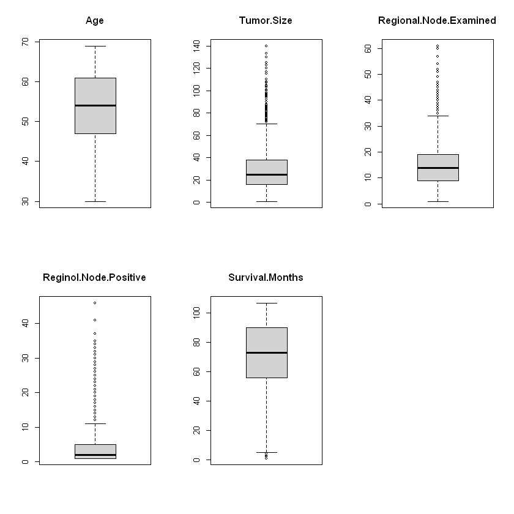

```r
# Select the columns that have numercal values
columns_of_interest <- c("Age", "Tumor.Size", "Regional.Node.Examined", "Reginol.Node.Positive", "Survival.Months")
data_of_interest <- dataset[, columns_of_interest]

# Create boxplots for each selected attribute
par(mfrow = c(2, 3))  # Adjust the layout as needed

for (attribute in columns_of_interest) {
  boxplot(data_of_interest[[attribute]], main = attribute)
}
```

we have represented the dataset in the following graphs to provide better understanding:

# histogram for Age attribute

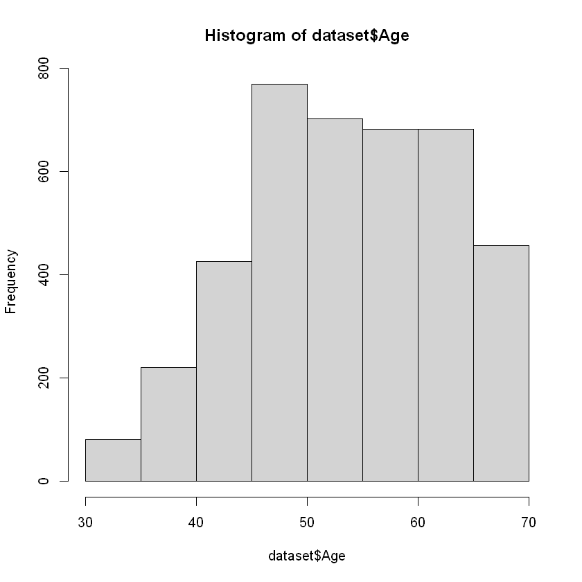

```r
hist(dataset$Age)
```

A histogram showing the age distribution of women diagnosed with breast cancer. We conclude that breast cancer is more common among women whose ages range from 45 to 50 years (highest frequency). However, it illustrates the wide range of ages, which could cause computation errors and necessitate transformation to bring the ages within a more manageable range.

# pie chart for Race attribute

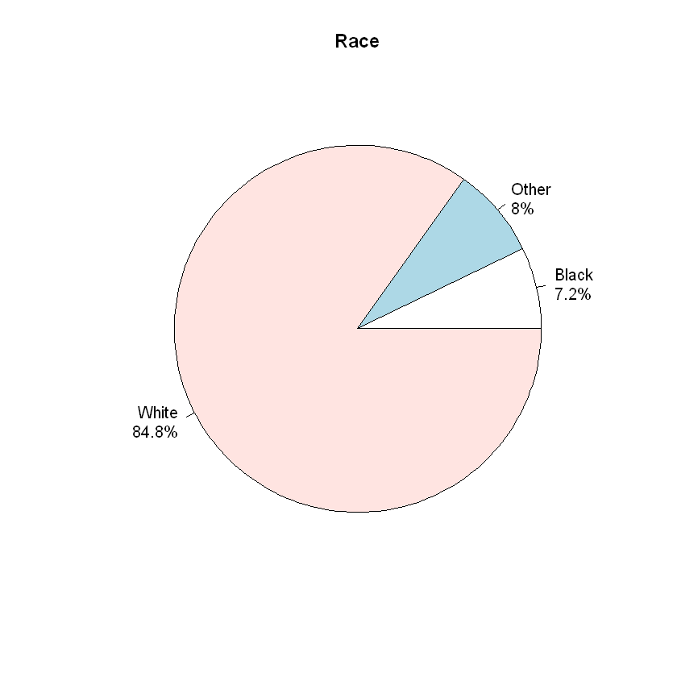

```r
library(dplyr)
tab = dataset$Race %>% table()
precentages = tab %>% prop.table() %>% round(3)*100
txt = paste0(names(tab), '\n', precentages, '%')
pie(tab, labels = txt, main= 'Race')
```

we can see that the race is divided into three sections with their percentage ( as our dataset shows we have white, black , other). The pie chart shows which is the most Race diagnosed with breast cancer. as illustrated, the white race is the highest diagnosed race with 84.8% rate

# Scatter Plot

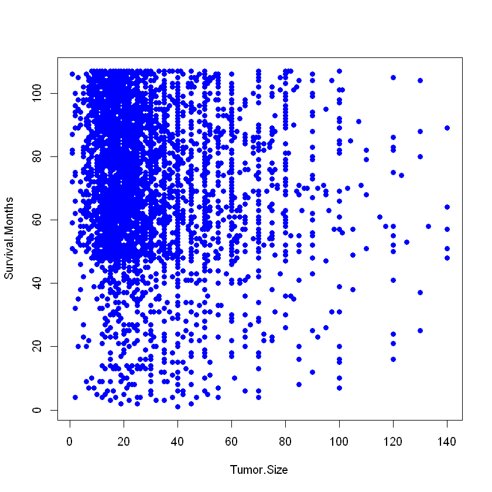

```r
with(dataset, plot(Tumor.Size, Survival.Months, col = "blue", pch = 16))
```

# detecting outliers

detecting outliers is crucial for data integrity, accurate analysis, model performance, and gaining a comprehensive understanding of the data. It helps identify potential data issues,also its important to detect it before starting the data preprocessing step since it can ensure that preprocessing steps are applied appropriately and that the resulting data is suitable

here we analyzed their occurrences for specific variables of the dataset, and deleted them here we found that the age has outliers not like what the boxplot indctated, for better results we chose to remove them and relay on this method instead of boxplot

```r
#install.packages("outliers")
library(outliers)
#outliers of age
outage= outlier(dataset$Age)
print(outage)
#number of rows that have the outlier
table(dataset$Age == outage )

#outliers of tumor size
outTumorSize = outlier(dataset$Tumor.Size)
print(outTumorSize)
#number of rows that has the outlier
table(dataset$Tumor.Size == outTumorSize)

#outliers of Regional Node Examined
outNodeExamined = outlier(dataset$Regional.Node.Examined)
print(outNodeExamined)
#number of rows that has the outlier
table(dataset$Regional.Node.Examined == outNodeExamined )

#outliers of Reginol Node Positive
outNodepositive = outlier(dataset$Reginol.Node.Positive)
print(outNodepositive)
#number of rows that has the outlier
table(dataset$Reginol.Node.Positive == outNodepositive )

#outliers of Survival Months
outmonth = outlier(dataset$Survival.Months)
print(outmonth)
#number of rows that has the outlier
table(dataset$Survival.Months==outmonth)
```

```
[1] 30
```

```
FALSE  TRUE
 4019     5
```

```
[1] 140
```

```
FALSE  TRUE
 4019     5
```

```
[1] 61
```

```
FALSE  TRUE
 4023     1
```

```
[1] 46
```

```
FALSE  TRUE
 4023     1
```

```
[1] 1
```

```
FALSE  TRUE
 4023     1
```

```r
#delete the outliers
dataset = dataset[dataset$Age != outage ,]
dataset = dataset[dataset$Tumor.Size != outTumorSize ,]
dataset = dataset[dataset$Regional.Node.Examined != outNodeExamined ,]
dataset = dataset[dataset$Reginol.Node.Positive != outNodepositive ,]
dataset = dataset[dataset$Survival.Months != outmonth ,]
nrow(dataset)
```

4011

# Data preprocessing:

# Data cleaning codes:

checking if there is any missing value or duplicated rows, this allow us to identify and handle data quality issues early in the analysis process

```r
is.na(dataset)
sum(is.na(dataset))
sum(duplicated(dataset))
#removing duplicate
dataset= unique(dataset)
sum(duplicated(dataset))
#number of rows after deleting dup
nrow(dataset)
nrow(dataset)
```

A matrix: 4011 × 16 of type lgl

[output not shown]

0

1

0

4010

4010

we did not have any missing valuse but we have a duplicated row so we deleted it.

# Data transformation codes:

# Normalization:

we had numeric attributes might be measured in different units or have a different range of values (Age, tumor size, Regional Node Examined, Regional Node Positive, Survival months). so we applied Normalization to adjust the quantities of each attribute so that they all fit into the same scale and they all have values between 0 and 1.

```r
#Define function normalize
normalize <- function(x) {return ((x - min(x)) / (max(x) - min(x)))}
#Call normalize function
dataset$Age<-normalize(dataset$Age)
dataset$Tumor.Size<-normalize(dataset$Tumor.Size)
dataset$Regional.Node.Examined<-normalize(dataset$Regional.Node.Examined)
dataset$Reginol.Node.Positive<-normalize(dataset$Reginol.Node.Positive)
dataset$Survival.Months<-normalize(dataset$Survival.Months)
#showing normalized columns
print(dataset)
```

```
            Age  Race Marital.Status T.Stage N.Stage X6th.Stage
1    0.97368421 White        Married      T1      N1        IIA
2    0.50000000 White        Married      T2      N2       IIIA
3    0.71052632 White       Divorced      T3      N3       IIIC
4    0.71052632 White        Married      T1      N1        IIA
5    0.42105263 White        Married      T2      N1        IIB
6    0.52631579 White        Single       T1      N1        IIA
7    0.52631579 White        Married      T1      N1        IIA
8    0.23684211 White        Married      T2      N1        IIB
9    0.23684211 White       Divorced      T4      N3       IIIC
10   1.00000000 White        Married      T4      N3       IIIC
11   0.97368421 White        Widowed      T1      N1        IIA
12   0.39473684 White        Married      T3      N1       IIIA
13   0.89473684 White        Married      T2      N1        IIB
14   0.44736842 White        Married      T1      N2       IIIA
```

[output cut: 16029 more lines]

# Encoding

The goal of this code is to convert categorical variables in the dataset into a numeric format. This process is called encoding. this making the dataset more accessible and suitable for machine learning algorithms that require numerical input for training and making predictions.

```r
dataset$Race = factor(dataset$Race,levels = c("White","Black", "Other"), labels=c(1,2,3))
dataset$Marital.Status = factor(dataset$Marital.Status,levels = c("Married","Divorced","Separated","Single ","Widowed"), labels=c(1,2,3,4,5))
dataset$differentiate = factor(dataset$differentiate,levels = c("Well differentiated","Moderately differentiated", "Poorly differentiated","Undifferentiated"), labels=c(1,2,3,4))
dataset$Grade= factor(dataset$Grade,levels = c(1 , 2 ,3 ," anaplastic; Grade IV"), labels=c(1,2,3,4))
dataset$X6th.Stage = factor(dataset$X6th.Stage,levels = c("IIA","IIIA", "IIB","IIIB","IIIC"), labels=c(1,2,3,4,5))
dataset$Status = factor(dataset$Status,levels = c("Dead","Alive"), labels=c(0,1))
dataset$Estrogen.Status = factor(dataset$Estrogen.Status ,levels = c("Negative","Positive"), labels=c(0,1))
dataset$Progesterone.Status = factor(dataset$Progesterone.Status ,levels = c("Negative","Positive"), labels=c(0,1))
dataset$A.Stage	 = factor(dataset$A.Stage	,levels = c("Regional","Distant"), labels=c(0,1))
dataset$T.Stage	 = factor(dataset$T.Stage	,levels = c("T1","T2","T3","T4"), labels=c(1,2,3,4))
dataset$N.Stage	 = factor(dataset$N.Stage	,levels = c("N1","N2","N3"), labels=c(1,2,3))
View(dataset)
```

A data.frame: 4010 × 16

|  | Age <dbl> | Race <fct> | Marital.Status <fct> | T.Stage <fct> | N.Stage <fct> | X6th.Stage <fct> | differentiate <fct> | Grade <fct> | A.Stage <fct> | Tumor.Size <dbl> | Estrogen.Status <fct> | Progesterone.Status <fct> | Regional.Node.Examined <dbl> | Reginol.Node.Positive <dbl> | Survival.Months <dbl> | Status <fct> |
| --- | --- | --- | --- | --- | --- | --- | --- | --- | --- | --- | --- | --- | --- | --- | --- | --- |
| 1 | 0.9736842 | 1 | 1 | 1 | 1 | 1 | 3 | 3 | 0 | 0.02272727 | 1 | 1 | 0.38983051 | 0.000 | 0.5523810 | 1 |
| 2 | 0.5000000 | 1 | 1 | 2 | 2 | 2 | 2 | 2 | 0 | 0.25757576 | 1 | 1 | 0.22033898 | 0.100 | 0.5714286 | 1 |
| 3 | 0.7105263 | 1 | 2 | 3 | 3 | 5 | 2 | 2 | 0 | 0.46969697 | 1 | 1 | 0.22033898 | 0.150 | 0.6952381 | 1 |
| 4 | 0.7105263 | 1 | 1 | 1 | 1 | 1 | 3 | 3 | 0 | 0.12878788 | 1 | 1 | 0.01694915 | 0.000 | 0.7809524 | 1 |
| 5 | 0.4210526 | 1 | 1 | 2 | 1 | 3 | 3 | 3 | 0 | 0.30303030 | 1 | 1 | 0.03389831 | 0.000 | 0.4571429 | 1 |
| 6 | 0.5263158 | 1 | 4 | 1 | 1 | 1 | 2 | 2 | 0 | 0.14393939 | 1 | 1 | 0.28813559 | 0.025 | 0.8285714 | 1 |
| 7 | 0.5263158 | 1 | 1 | 1 | 1 | 1 | 1 | 1 | 0 | 0.05303030 | 1 | 1 | 0.16949153 | 0.000 | 0.4952381 | 1 |
| 8 | 0.2368421 | 1 | 1 | 2 | 1 | 3 | 2 | 2 | 0 | 0.21969697 | 1 | 1 | 0.13559322 | 0.000 | 0.1142857 | 0 |
| 9 | 0.2368421 | 1 | 2 | 4 | 3 | 5 | 3 | 3 | 0 | 0.77272727 | 1 | 1 | 0.32203390 | 0.425 | 0.6476190 | 1 |
| 10 | 1.0000000 | 1 | 1 | 4 | 3 | 5 | 1 | 1 | 1 | 0.23484848 | 1 | 1 | 0.33898305 | 0.275 | 0.8571429 | 1 |
| 11 | 0.9736842 | 1 | 5 | 1 | 1 | 1 | 2 | 2 | 0 | 0.09090909 | 1 | 1 | 0.13559322 | 0.000 | 0.5904762 | 0 |
| 12 | 0.3947368 | 1 | 1 | 3 | 1 | 2 | 3 | 3 | 0 | 0.43939394 | 0 | 0 | 0.16949153 | 0.050 | 0.8571429 | 1 |
| 13 | 0.8947368 | 1 | 1 | 2 | 1 | 3 | 3 | 3 | 0 | 0.25757576 | 1 | 1 | 0.20338983 | 0.050 | 0.5142857 | 1 |
| 14 | 0.4473684 | 1 | 1 | 1 | 2 | 2 | 3 | 3 | 0 | 0.10606061 | 1 | 1 | 0.37288136 | 0.150 | 0.3428571 | 1 |
| 15 | 0.8157895 | 1 | 2 | 2 | 3 | 5 | 2 | 2 | 0 | 0.25757576 | 1 | 1 | 0.25423729 | 0.325 | 0.5904762 | 1 |
| 16 | 0.7894737 | 1 | 1 | 1 | 1 | 1 | 2 | 2 | 0 | 0.13636364 | 1 | 1 | 0.32203390 | 0.000 | 0.4476190 | 1 |
| 17 | 0.6578947 | 1 | 4 | 2 | 1 | 3 | 2 | 2 | 0 | 0.34090909 | 1 | 1 | 0.00000000 | 0.000 | 0.9809524 | 1 |
| 18 | 0.3157895 | 1 | 1 | 2 | 1 | 3 | 2 | 2 | 0 | 0.17424242 | 1 | 1 | 0.35593220 | 0.000 | 0.5714286 | 1 |
| 19 | 0.4473684 | 2 | 2 | 2 | 1 | 3 | 2 | 2 | 0 | 0.18181818 | 1 | 1 | 0.25423729 | 0.000 | 1.0000000 | 1 |
| 20 | 0.7631579 | 1 | 2 | 2 | 1 | 3 | 2 | 2 | 0 | 0.21212121 | 0 | 0 | 0.32203390 | 0.000 | 0.7142857 | 1 |
| 21 | 0.4473684 | 3 | 1 | 2 | 1 | 3 | 1 | 1 | 0 | 0.21969697 | 1 | 1 | 0.23728814 | 0.025 | 0.7523810 | 1 |
| 22 | 0.6842105 | 1 | 1 | 2 | 2 | 2 | 2 | 2 | 0 | 0.29545455 | 1 | 1 | 0.23728814 | 0.100 | 0.4571429 | 1 |
| 23 | 0.6315789 | 1 | 4 | 2 | 1 | 3 | 3 | 3 | 0 | 0.21212121 | 1 | 1 | 0.05084746 | 0.000 | 0.7238095 | 1 |
| 24 | 0.4473684 | 1 | 1 | 3 | 1 | 2 | 3 | 3 | 0 | 0.52272727 | 1 | 0 | 0.28813559 | 0.000 | 0.9523810 | 1 |
| 25 | 0.8157895 | 1 | 1 | 1 | 3 | 5 | 3 | 3 | 0 | 0.14393939 | 1 | 1 | 0.42372881 | 0.525 | 0.9142857 | 1 |
| 26 | 0.8421053 | 1 | 1 | 2 | 3 | 5 | 2 | 2 | 0 | 0.15909091 | 1 | 1 | 0.50847458 | 0.400 | 0.6476190 | 1 |
| 27 | 0.4473684 | 1 | 1 | 2 | 3 | 5 | 3 | 3 | 0 | 0.37121212 | 1 | 1 | 0.40677966 | 0.550 | 0.9523810 | 1 |
| 28 | 0.3947368 | 1 | 1 | 1 | 1 | 1 | 1 | 1 | 0 | 0.12121212 | 1 | 1 | 0.22033898 | 0.000 | 0.7619048 | 1 |
| 29 | 0.6842105 | 1 | 2 | 2 | 2 | 2 | 1 | 1 | 0 | 0.18181818 | 1 | 0 | 0.22033898 | 0.075 | 0.5904762 | 1 |
| 30 | 0.9210526 | 1 | 1 | 2 | 1 | 3 | 3 | 3 | 0 | 0.15151515 | 1 | 1 | 0.15254237 | 0.000 | 0.8000000 | 1 |
| ⋮ | ⋮ | ⋮ | ⋮ | ⋮ | ⋮ | ⋮ | ⋮ | ⋮ | ⋮ | ⋮ | ⋮ | ⋮ | ⋮ | ⋮ | ⋮ | ⋮ |
| 3995 | 0.5263158 | 1 | 4 | 1 | 1 | 1 | 2 | 2 | 0 | 0.007575758 | 1 | 1 | 0.30508475 | 0.025 | 0.4571429 | 1 |
| 3996 | 0.8157895 | 1 | 4 | 2 | 3 | 5 | 2 | 2 | 0 | 0.181818182 | 1 | 0 | 0.27118644 | 0.325 | 0.6380952 | 1 |
| 3997 | 1.0000000 | 1 | 1 | 1 | 2 | 2 | 2 | 2 | 0 | 0.136363636 | 1 | 1 | 0.33898305 | 0.200 | 0.8190476 | 0 |
| 3998 | 0.1052632 | 3 | 1 | 1 | 1 | 1 | 2 | 2 | 0 | 0.136363636 | 1 | 1 | 0.23728814 | 0.025 | 0.5142857 | 1 |
| 3999 | 0.9736842 | 1 | 2 | 1 | 1 | 1 | 1 | 1 | 0 | 0.128787879 | 1 | 1 | 0.16949153 | 0.000 | 0.9333333 | 1 |
| 4000 | 0.5789474 | 1 | 1 | 2 | 2 | 2 | 2 | 2 | 0 | 0.219696970 | 1 | 1 | 0.18644068 | 0.100 | 0.7904762 | 1 |
| 4001 | 0.0000000 | 1 | 2 | 2 | 1 | 3 | 3 | 3 | 0 | 0.333333333 | 1 | 1 | 0.20338983 | 0.025 | 0.5809524 | 1 |
| 4002 | 0.6315789 | 1 | 1 | 2 | 1 | 3 | 2 | 2 | 0 | 0.333333333 | 1 | 1 | 0.25423729 | 0.000 | 0.2095238 | 1 |
| 4003 | 0.6842105 | 1 | 2 | 1 | 1 | 1 | 1 | 1 | 0 | 0.106060606 | 1 | 1 | 0.06779661 | 0.000 | 0.5619048 | 1 |
| 4004 | 0.9210526 | 1 | 2 | 1 | 2 | 2 | 2 | 2 | 0 | 0.136363636 | 1 | 1 | 0.33898305 | 0.150 | 0.5904762 | 0 |
| 4005 | 0.7105263 | 1 | 1 | 2 | 2 | 2 | 2 | 2 | 0 | 0.174242424 | 1 | 0 | 0.30508475 | 0.200 | 0.6000000 | 0 |
| 4006 | 0.9736842 | 1 | 1 | 2 | 1 | 3 | 2 | 2 | 0 | 0.295454545 | 1 | 0 | 0.22033898 | 0.025 | 0.7047619 | 1 |
| 4007 | 0.2631579 | 3 | 1 | 2 | 1 | 3 | 3 | 3 | 0 | 0.257575758 | 0 | 0 | 0.28813559 | 0.025 | 0.6095238 | 1 |
| 4008 | 0.3421053 | 1 | 4 | 4 | 1 | 4 | 2 | 2 | 0 | 0.151515152 | 1 | 1 | 0.15254237 | 0.000 | 0.6952381 | 1 |
| 4009 | 0.7631579 | 1 | 4 | 1 | 1 | 1 | 1 | 1 | 0 | 0.128787879 | 1 | 1 | 0.30508475 | 0.025 | 0.4761905 | 1 |
| 4010 | 0.5789474 | 1 | 2 | 3 | 1 | 2 | 2 | 2 | 0 | 0.750000000 | 1 | 0 | 0.32203390 | 0.000 | 1.0000000 | 1 |
| 4011 | 0.7368421 | 2 | 4 | 2 | 1 | 3 | 3 | 3 | 0 | 0.166666667 | 1 | 0 | 0.08474576 | 0.000 | 0.2380952 | 0 |
| 4012 | 0.8157895 | 1 | 5 | 2 | 2 | 2 | 2 | 2 | 0 | 0.181818182 | 1 | 1 | 0.38983051 | 0.075 | 0.9333333 | 1 |
| 4013 | 0.5263158 | 1 | 1 | 3 | 3 | 5 | 3 | 3 | 0 | 0.598484848 | 1 | 1 | 0.32203390 | 0.275 | 0.7333333 | 1 |
| 4014 | 0.9736842 | 1 | 1 | 1 | 1 | 1 | 1 | 1 | 0 | 0.106060606 | 0 | 0 | 0.15254237 | 0.000 | 0.9523810 | 1 |
| 4015 | 0.2368421 | 1 | 1 | 3 | 1 | 2 | 2 | 2 | 0 | 0.507575758 | 1 | 1 | 0.35593220 | 0.025 | 0.8000000 | 1 |
| 4016 | 0.8947368 | 1 | 1 | 2 | 2 | 2 | 2 | 2 | 0 | 0.295454545 | 1 | 1 | 0.05084746 | 0.075 | 0.6285714 | 1 |
| 4017 | 0.6052632 | 1 | 1 | 2 | 1 | 3 | 1 | 1 | 0 | 0.371212121 | 1 | 1 | 0.47457627 | 0.025 | 0.4761905 | 1 |
| 4018 | 0.3947368 | 1 | 1 | 2 | 1 | 3 | 2 | 2 | 0 | 0.204545455 | 0 | 0 | 0.01694915 | 0.000 | 0.1619048 | 0 |
| 4019 | 0.8684211 | 1 | 1 | 1 | 1 | 1 | 2 | 2 | 0 | 0.068181818 | 1 | 1 | 0.16949153 | 0.000 | 0.6476190 | 1 |
| 4020 | 0.8157895 | 3 | 1 | 1 | 1 | 1 | 2 | 2 | 0 | 0.060606061 | 1 | 1 | 0.00000000 | 0.000 | 0.4476190 | 1 |
| 4021 | 0.6578947 | 1 | 2 | 2 | 2 | 2 | 2 | 2 | 0 | 0.340909091 | 1 | 1 | 0.22033898 | 0.175 | 0.6380952 | 1 |
| 4022 | 0.9736842 | 1 | 1 | 2 | 1 | 3 | 2 | 2 | 0 | 0.159090909 | 1 | 0 | 0.16949153 | 0.050 | 0.6380952 | 1 |
| 4023 | 0.7105263 | 2 | 2 | 2 | 1 | 3 | 2 | 2 | 0 | 0.325757576 | 1 | 1 | 0.16949153 | 0.000 | 0.6666667 | 1 |
| 4024 | 0.3947368 | 1 | 1 | 2 | 1 | 3 | 2 | 2 | 0 | 0.219696970 | 1 | 1 | 0.10169492 | 0.025 | 0.9333333 | 1 |

```r
is.na(dataset)
sum(is.na(dataset))
```

A matrix: 4010 × 16 of type lgl

[output not shown]

0

# the chi-square

this code is conducting a series of chi-square tests to assess the association between each categorical attribute in the dataset and the "Status" variable.

```r
# Get the column names of the dataset
column_names <- colnames(dataset)

# Perform chi-square test for each attribute
for (attribute in column_names) {
  if (attribute != "Status") {
    # Create a contingency table
    contingency_table <- table(dataset[[attribute]], dataset$Status)

    # Perform chi-square test
    result <- chisq.test(contingency_table)

    # Print the attribute name and the result
    cat("Attribute:", attribute, "\n")
    print(result)
    cat("\n")
  }
}
```

```
Attribute: Age

	Pearson's Chi-squared test

data:  contingency_table
X-squared = 85.576, df = 38, p-value = 1.588e-05


Attribute: Race

	Pearson's Chi-squared test

data:  contingency_table
X-squared = 28.288, df = 2, p-value = 7.201e-07


Attribute: Marital.Status

	Pearson's Chi-squared test

data:  contingency_table
X-squared = 28.117, df = 4, p-value = 1.181e-05


Attribute: T.Stage

	Pearson's Chi-squared test

data:  contingency_table
X-squared = 104.17, df = 3, p-value < 2.2e-16


Attribute: N.Stage

	Pearson's Chi-squared test

data:  contingency_table
X-squared = 266.71, df = 2, p-value < 2.2e-16


Attribute: X6th.Stage

	Pearson's Chi-squared test

data:  contingency_table
X-squared = 278.71, df = 4, p-value < 2.2e-16
```

```
Attribute: differentiate

	Pearson's Chi-squared test

data:  contingency_table
X-squared = 108.13, df = 3, p-value < 2.2e-16
```

```
Attribute: Grade

	Pearson's Chi-squared test

data:  contingency_table
X-squared = 108.13, df = 3, p-value < 2.2e-16


Attribute: A.Stage

	Pearson's Chi-squared test with Yates' continuity correction

data:  contingency_table
X-squared = 36.006, df = 1, p-value = 1.967e-09
```

```
Attribute: Tumor.Size

	Pearson's Chi-squared test

data:  contingency_table
X-squared = 187.56, df = 108, p-value = 3.248e-06


Attribute: Estrogen.Status

	Pearson's Chi-squared test with Yates' continuity correction

data:  contingency_table
X-squared = 127.14, df = 1, p-value < 2.2e-16


Attribute: Progesterone.Status

	Pearson's Chi-squared test with Yates' continuity correction

data:  contingency_table
X-squared = 120.01, df = 1, p-value < 2.2e-16
```

```
Attribute: Regional.Node.Examined

	Pearson's Chi-squared test

data:  contingency_table
X-squared = 66.688, df = 51, p-value = 0.06914
```

```
Attribute: Reginol.Node.Positive

	Pearson's Chi-squared test

data:  contingency_table
X-squared = 336.52, df = 36, p-value < 2.2e-16
```

```
Attribute: Survival.Months

	Pearson's Chi-squared test

data:  contingency_table
X-squared = 1556.6, df = 105, p-value < 2.2e-16
```

# correlation analysis

This code extracts numeric attributes from the dataset, calculates the correlation matrix for those numeric variables, and then prints the correlation matrix.

```r
numeric_datas <- dataset[, sapply(dataset, is.numeric)]

# Calculate the correlation matrix for numeric variables
correlation_matrix <- cor(numeric_datas)

# Print the correlation matrix
print(correlation_matrix)
```

```
                               Age  Tumor.Size Regional.Node.Examined
Age                     1.00000000 -0.07535055            -0.03198520
Tumor.Size             -0.07535055  1.00000000             0.10109924
Regional.Node.Examined -0.03198520  0.10109924             1.00000000
Reginol.Node.Positive   0.01477105  0.24556600             0.40615249
Survival.Months        -0.01143674 -0.08466962            -0.01916882
                       Reginol.Node.Positive Survival.Months
Age                               0.01477105     -0.01143674
Tumor.Size                        0.24556600     -0.08466962
Regional.Node.Examined            0.40615249     -0.01916882
Reginol.Node.Positive             1.00000000     -0.13344498
Survival.Months                  -0.13344498      1.00000000
```

The matrix shows the correlation coefficients between pairs of variables. The values range from -1 to 1, where -1 indicates a perfect negative correlation, 1 indicates a perfect positive correlation, and 0 indicates no correlation. For example, looking at "Tumor.Size" and "Reginol.Node.Positive," the correlation coefficient is 0.245566, indicating a positive correlation which means that the larger tumor size the greater number of nodes affected . In contrast, "Reginol.Node.Positive" and "Survival.Months" have a correlation coefficient of -0.13344498 which means the greater number of affected nodes the fewer months to live

# feature selection

other way to choose the relevant attributes to the dataset, we performed this feature selection if you want to check it out, although we think the chi square is better # ensure the results are repeatable

# this the code but we didn't apply it

set.seed(7) library(mlbench) library(caret)

features <- dataset[, -c(2 , 3 ,16)] # Exclude non-numeric and target variable columns target <- dataset$Status

ctrl <- rfeControl(functions = rfFuncs, method = "cv", number = 10) # 10-fold cross-validation

rfe_result <- rfe(features, target, sizes = 1:ncol(features), rfeControl = ctrl)

print(rfe_result) plot(rfe_result)

# Classification

For classification applied three different classification algorithms ID3 with information gain, CART with Gini index, and C4.5 (C5.0) with gain ratio for each size ( 70% 30% , 60% 40% , 80% 20% ). . -For the ID3 algorithm, we utilized the rpart package with the information split method, and the resulting decision tree was visualized and evaluated using confusion matrix, sensitivity, specificity, precision, and accuracy. -For the CART algorithm, we used the gini split method with the rpart package, visualized the decision tree, and evaluated the model's performance using confusion matrix, sensitivity, specificity, precision, and accuracy. -For the C4.5 (C5.0) algorithm, we employed the C50 package and visualized the decision tree using the party and partykit packages, then evaluated using confusion matrix, sensitivity, specificity, precision, and accuracy.

# Tree 1 70% training and 30% testing using infomation gain

```r
dataset$Status <- factor(dataset$Status)
# Set the random seed for reproducibility
set.seed(1234)

# Split the dataset into training 70% and testing 30% subsets
ind <- sample(1:nrow(dataset), size = floor(0.7 * nrow(dataset)), replace = FALSE)
trainData <- dataset[ind,]
testData <- dataset[-ind,]
myFormula <- Status ~ Age + Marital.Status + Race + T.Stage + N.Stage + X6th.Stage + differentiate + Grade + A.Stage + Tumor.Size + Estrogen.Status + Progesterone.Status + Reginol.Node.Positive + Regional.Node.Examined + Survival.Months
```

```r
# Load the necessary library
install.packages('party')
library(party)
install.packages("rpart")
install.packages('rpart.plot')
library('rpart.plot')
library(rpart)
#tree 1 for information gain
# Using ID3 with rpart
dataset.id3 <- rpart(myFormula, data = trainData, method = "class", parms = list(split = "information"))
printcp(dataset.id3)  # Display cp table for pruning
```

```
Classification tree:
rpart(formula = myFormula, data = trainData, method = "class",
    parms = list(split = "information"))

Variables actually used in tree construction:
[1] Age                   Estrogen.Status       Reginol.Node.Positive
[4] Survival.Months

Root node error: 405/2807 = 0.14428

n= 2807

        CP nsplit rel error  xerror     xstd
1 0.348148      0   1.00000 1.00000 0.045966
2 0.015638      1   0.65185 0.65185 0.038186
3 0.014815      4   0.60494 0.65679 0.038315
4 0.010000      5   0.59012 0.63951 0.037859
```

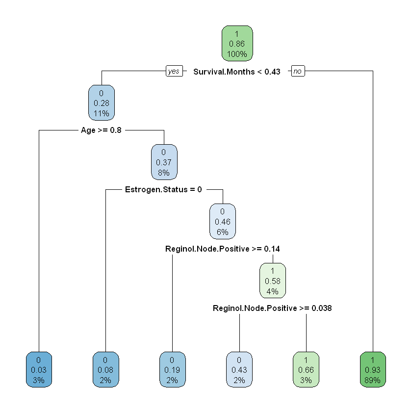

```r
# Plot the decision tree1
rpart.plot(dataset.id3)
```

```r
# Make predictions on the test set
testPred <- predict(dataset.id3, newdata = testData, type = "class")
result <- table(testPred, testData$Status)
```

```r
#Evaluate the model:
install.packages("caret")
install.packages('e1071', dependencies=TRUE)
library(e1071)
library(caret)
co_result <- confusionMatrix(result)
print(co_result)
sensitivity(as.table(co_result))
specificity(as.table(co_result))
precision(as.table(co_result))
acc <- co_result$overall["Accuracy"]
acc
```

```
Confusion Matrix and Statistics


testPred   0   1
       0  91  23
       1 116 973

               Accuracy : 0.8845
                 95% CI : (0.865, 0.902)
    No Information Rate : 0.8279
    P-Value [Acc > NIR] : 3.154e-08

                  Kappa : 0.5067

 Mcnemar's Test P-Value : 6.029e-15

            Sensitivity : 0.43961
            Specificity : 0.97691
         Pos Pred Value : 0.79825
         Neg Pred Value : 0.89348
             Prevalence : 0.17207
         Detection Rate : 0.07564
   Detection Prevalence : 0.09476
      Balanced Accuracy : 0.70826

       'Positive' Class : 0
```

0.439613526570048

0.976907630522088

0.798245614035088

**Accuracy:** 0.884455527847049

The formula myFormula is used to define the target variable (Status) and predictor variables for the classification. We made decision tree classification using the ID3 algorithm (information gain) on a dataset then we split the dataset into 70% training and 30% testing. For visualization the tree In this case, the output lists the variables that are actually used in constructing the classification tree which are the following variables are used: Age, Estrogen.Status, Reginol.Node.Positive, Survival.Months to know the status (0 dead, 1 alive). Survival months has the highest Information Gain so it's chosen as the splitting criterion at each node of the decision tree.

For the Predictions , they are made on the test set using the trained decision tree. we calculated confusion matrix, sensitivity, specificity, precision, and overall accuracy . And the accuracy was high(88.4%) which indicates that a significant portion of the predictions made by the model match the actual outcomes in the test dataset as well as the other measurments.

# Tree 2 70% training and 30% testing using gini index

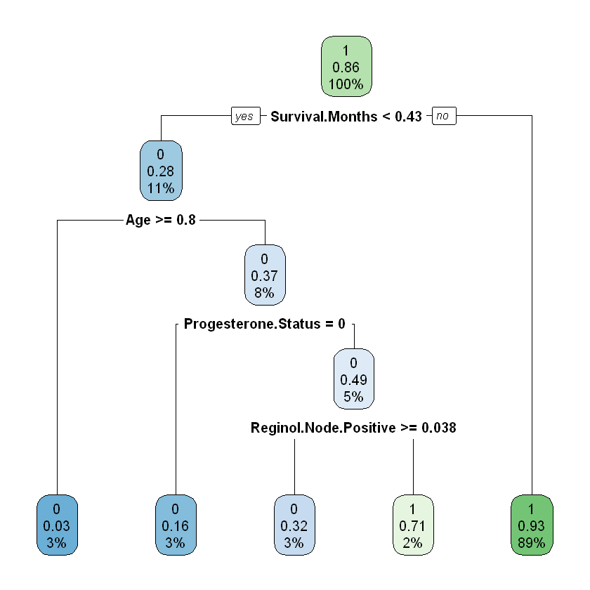

```r
# Using CART with rpart
#tree 2 using gini index
dataset.cart <- rpart(myFormula, data = trainData, method = "class", parms = list(split = "gini"))
# Plot the decision tree
library(rpart.plot)
rpart.plot(dataset.cart)
```

```r
#the result
testPredc <- predict(dataset.cart, newdata = testData, type = "class")
resultc <- table(testPredc, testData$Status)
```

```r
#Evaluate the model:
co_resultc <- confusionMatrix(resultc)
print(co_resultc)
sensitivity(as.table(co_resultc))
specificity(as.table(co_resultc))
precision(as.table(co_resultc))
accc <- co_resultc$overall["Accuracy"]
accc
```

```
Confusion Matrix and Statistics


testPredc   0   1
        0  96  23
        1 111 973

               Accuracy : 0.8886
                 95% CI : (0.8695, 0.9058)
    No Information Rate : 0.8279
    P-Value [Acc > NIR] : 2.665e-09

                  Kappa : 0.5299

 Mcnemar's Test P-Value : 5.663e-14

            Sensitivity : 0.46377
            Specificity : 0.97691
         Pos Pred Value : 0.80672
         Neg Pred Value : 0.89760
             Prevalence : 0.17207
         Detection Rate : 0.07980
   Detection Prevalence : 0.09892
      Balanced Accuracy : 0.72034

       'Positive' Class : 0
```

0.463768115942029

0.976907630522088

0.80672268907563

**Accuracy:** 0.888611803823774

# Tree 3 70% training and 30% testing using gain ratio

```r
#tree3 using gain ratio
# Install and load the C50 package if not already installed
# install.packages("C50")
library(C50)
library(partykit)
library(party)
# Using C4.5 (C5.0) with C50
dataset.c45 <- C5.0(myFormula, data = trainData)
# Print the tree rules
summary(dataset.c45)
```

```
Call:
C5.0.formula(formula = myFormula, data = trainData)


C5.0 [Release 2.07 GPL Edition]  	Sun Dec  3 00:20:37 2023
-------------------------------

Class specified by attribute `outcome'

Read 2807 cases (16 attributes) from undefined.data

Decision tree:

Survival.Months > 0.4285714: 1 (2488/175)
Survival.Months <= 0.4285714:
:...Age > 0.7894737: 0 (87/3)
    Age <= 0.7894737:
    :...Estrogen.Status = 0: 0 (52/4)
        Estrogen.Status = 1:
        :...Reginol.Node.Positive > 0.125: 0 (57/11)
            Reginol.Node.Positive <= 0.125:
            :...Progesterone.Status = 0: 0 (23/9)
                Progesterone.Status = 1:
                :...Marital.Status = 3: 0 (1)
                    Marital.Status in {4,5}: 1 (20/7)
                    Marital.Status = 2:
                    :...X6th.Stage in {1,2,5}: 0 (7)
                    :   X6th.Stage in {3,4}: 1 (5/1)
                    Marital.Status = 1:
                    :...Reginol.Node.Positive <= 0: 1 (28/4)
                        Reginol.Node.Positive > 0:
                        :...T.Stage = 4: 1 (0)
                            T.Stage in {1,3}: 0 (20/8)
                            T.Stage = 2:
                            :...Survival.Months <= 0.247619: 1 (10)
                                Survival.Months > 0.247619: 0 (9/3)


Evaluation on training data (2807 cases):

```

[output cut: 11 more lines]

```


	Attribute usage:

	100.00%	Survival.Months
	 11.36%	Age
	  8.27%	Estrogen.Status
	  6.41%	Reginol.Node.Positive
	  4.38%	Progesterone.Status
	  3.56%	Marital.Status
	  1.39%	T.Stage
	  0.43%	X6th.Stage


Time: 0.0 secs
```

```r
# Make predictions on the test set
testPreds <- predict(dataset.c45, newdata = testData)
results <- table(testPreds, testData$Status)
c45_party <- as.party(dataset.c45)
```

[figure not shown]

```r
# Plot the decision tree
plot(c45_party)
```

```r
#Evaluate the model:
#install.packages("caret")
#install.packages('e1071', dependencies=TRUE)
library(e1071)
library(caret)

co_results <- confusionMatrix(results)
print(co_results)
sensitivity(as.table(co_results))
specificity(as.table(co_results))
precision(as.table(co_results))
accs <- co_results$overall["Accuracy"]
accs
```

```
Confusion Matrix and Statistics


testPreds   0   1
        0  96  26
        1 111 970

               Accuracy : 0.8861
                 95% CI : (0.8668, 0.9035)
    No Information Rate : 0.8279
    P-Value [Acc > NIR] : 1.202e-08

                  Kappa : 0.5227

 Mcnemar's Test P-Value : 7.146e-13

            Sensitivity : 0.4638
            Specificity : 0.9739
         Pos Pred Value : 0.7869
         Neg Pred Value : 0.8973
             Prevalence : 0.1721
         Detection Rate : 0.0798
   Detection Prevalence : 0.1014
      Balanced Accuracy : 0.7188

       'Positive' Class : 0
```

0.463768115942029

0.973895582329317

0.786885245901639

**Accuracy:** 0.886118038237739

# Tree 4 80% training and 20% testing using information gain

```r
# Split the dataset into 80% training and 20% testing subsets
indfo <- sample(1:nrow(dataset), size = floor(0.8 * nrow(dataset)), replace = FALSE)
train.Data <- dataset[indfo,]
test.Data <- dataset[-indfo,]
```

```
n= 3208

node), split, n, loss, yval, (yprob)
      * denotes terminal node

 1) root 3208 491 1 (0.15305486 0.84694514)
   2) Survival.Months< 0.4333333 368  97 0 (0.73641304 0.26358696)
     4) Age>=0.8026316 109   7 0 (0.93577982 0.06422018) *
     5) Age< 0.8026316 259  90 0 (0.65250965 0.34749035)
      10) Estrogen.Status=0 61   4 0 (0.93442623 0.06557377) *
      11) Estrogen.Status=1 198  86 0 (0.56565657 0.43434343)
        22) X6th.Stage=2,4,5 101  26 0 (0.74257426 0.25742574) *
        23) X6th.Stage=1,3 97  37 1 (0.38144330 0.61855670)
          46) Age>=0.6447368 22   7 0 (0.68181818 0.31818182) *
          47) Age< 0.6447368 75  22 1 (0.29333333 0.70666667) *
   3) Survival.Months>=0.4333333 2840 220 1 (0.07746479 0.92253521) *
```

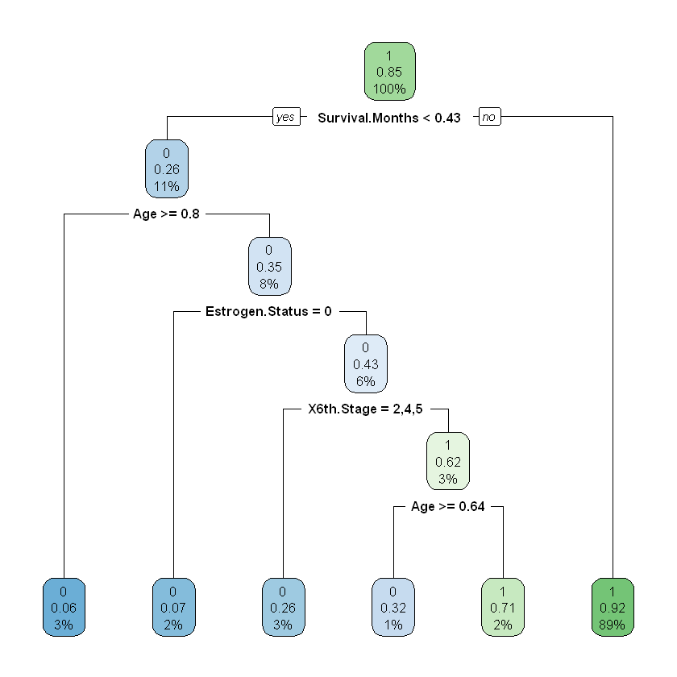

```r
# tree4 using information gain
# Using ID3 with rpart
datasetID3 <- rpart(myFormula, data = train.Data, method = "class", parms = list(split = "information"))
print(datasetID3)  # Display cp table for pruning

# Plot the decision tree
rpart.plot(datasetID3)
```

```r
# Make predictions on the test set
testPredec <- predict(datasetID3, newdata = test.Data, type = "class")
resultdd<- table(testPredec, test.Data$Status)
```

```r
#Evaluate the model:
#install.packages("caret")
#install.packages('e1071', dependencies=TRUE)
library(e1071)
library(caret)
coresult <- confusionMatrix(resultdd)
print(coresult)
sensitivity(as.table(coresult))
specificity(as.table(coresult))
precision(as.table(coresult))
accur<- coresult$overall["Accuracy"]
accur
```

```
Confusion Matrix and Statistics


testPredec   0   1
         0  60  19
         1  61 662

               Accuracy : 0.9002
                 95% CI : (0.8774, 0.9201)
    No Information Rate : 0.8491
    P-Value [Acc > NIR] : 1.332e-05

                  Kappa : 0.5459

 Mcnemar's Test P-Value : 4.563e-06

            Sensitivity : 0.49587
            Specificity : 0.97210
         Pos Pred Value : 0.75949
         Neg Pred Value : 0.91563
             Prevalence : 0.15087
         Detection Rate : 0.07481
   Detection Prevalence : 0.09850
      Balanced Accuracy : 0.73398

       'Positive' Class : 0
```

0.495867768595041

0.972099853157122

0.759493670886076

**Accuracy:** 0.900249376558603

The formula myFormula is used to define the target variable (Status) and predictor variables for the classification.

We made decision tree classification using the ID3 algorithm (information gain) on a dataset then we split the dataset into 80% training and 20% testing. For visualization the tree In this case, the output lists the variables that are actually used in constructing the classification tree which are the following variables are used: Age, Estrogen.Status, X6TH.Stage, Survival.Months to know the status (0 dead, 1 alive). Survival months has the highest Information Gain so it's chosen as the splitting criterion at each node of the decision tree.

For the Predictions , they are made on the test set using the trained decision tree. we calculated confusion matrix, sensitivity, specificity, precision, and overall accuracy . And the accuracy was high(90%) which indicates that a significant portion of the predictions made by the model match the actual outcomes in the test dataset.

# Tree 5 80% training and 20% testing using gini index

[figure not shown]

```r
#tree5 using gini index
# Using CART with rpart
datasetcart <- rpart(myFormula, data = train.Data, method = "class", parms = list(split = "gini"))

# Plot the decision tree
library(rpart.plot)
rpart.plot(dataset.cart)
```

```r
#result
testPredcs<- predict(datasetcart, newdata = test.Data, type = "class")
resultcs <- table(testPredcs, test.Data$Status)
```

```r
#Evaluate the model:
co_resultcg <- confusionMatrix(resultcs)
print(co_resultcg)
sensitivity(as.table(co_resultcg))
specificity(as.table(co_resultcg))
precision(as.table(co_resultcg))
acccu<- co_resultcg$overall["Accuracy"]
acccu
```

```
Confusion Matrix and Statistics


testPredcs   0   1
         0  63  18
         1  58 663

               Accuracy : 0.9052
                 95% CI : (0.8828, 0.9246)
    No Information Rate : 0.8491
    P-Value [Acc > NIR] : 1.699e-06

                  Kappa : 0.572

 Mcnemar's Test P-Value : 7.691e-06

            Sensitivity : 0.52066
            Specificity : 0.97357
         Pos Pred Value : 0.77778
         Neg Pred Value : 0.91956
             Prevalence : 0.15087
         Detection Rate : 0.07855
   Detection Prevalence : 0.10100
      Balanced Accuracy : 0.74711

       'Positive' Class : 0
```

0.520661157024793

0.973568281938326

0.777777777777778

**Accuracy:** 0.905236907730673

For the Predictions , they are made on the test set using the trained decision tree. we calculated confusion matrix, sensitivity, specificity, precision, and overall accuracy . And the accuracy was high(90.5%) which indicates that a significant portion of the predictions made by the model match the actual outcomes in the test dataset as well as the other measurements.

# Tree 6 80% training and 20% testing using gain ratio

```r
#tree6 using gain ratio
# Install and load the C50 package if not already installed
# install.packages("C50")
library(C50)
library(partykit)
library(party)
# Using C4.5 (C5.0) with C50
datasetc45 <- C5.0(myFormula, data = train.Data)
# Print the tree rules
summary(datasetc45)
```

```
Call:
C5.0.formula(formula = myFormula, data = train.Data)


C5.0 [Release 2.07 GPL Edition]  	Sun Dec  3 00:20:39 2023
-------------------------------

Class specified by attribute `outcome'

Read 3208 cases (16 attributes) from undefined.data

Decision tree:

Survival.Months > 0.4285714: 1 (2840/220)
Survival.Months <= 0.4285714:
:...Estrogen.Status = 0: 0 (75/4)
    Estrogen.Status = 1:
    :...Age > 0.7894737: 0 (95/7)
        Age <= 0.7894737:
        :...N.Stage in {2,3}: 0 (92/23)
            N.Stage = 1:
            :...Age > 0.6578947: 0 (22/6)
                Age <= 0.6578947:
                :...Progesterone.Status = 1: 1 (72/20)
                    Progesterone.Status = 0:
                    :...Reginol.Node.Positive <= 0: 0 (4)
                        Reginol.Node.Positive > 0: 1 (8/3)


Evaluation on training data (3208 cases):

	    Decision Tree
	  ----------------
	  Size      Errors

	     8  283( 8.8%)   <<


	   (a)   (b)    <-classified as
	  ----  ----
	   248   243    (a): class 0
	    40  2677    (b): class 1


	Attribute usage:

	100.00%	Survival.Months
	 11.47%	Estrogen.Status
	  9.13%	Age
	  6.17%	N.Stage
	  2.62%	Progesterone.Status
	  0.37%	Reginol.Node.Positive


Time: 0.0 secs
```

```r
# Make predictions on the test set
testPredsn <- predict(datasetc45, newdata = test.Data)
resultsn<- table(testPredsn, test.Data$Status)
c45party <- as.party(datasetc45)
```

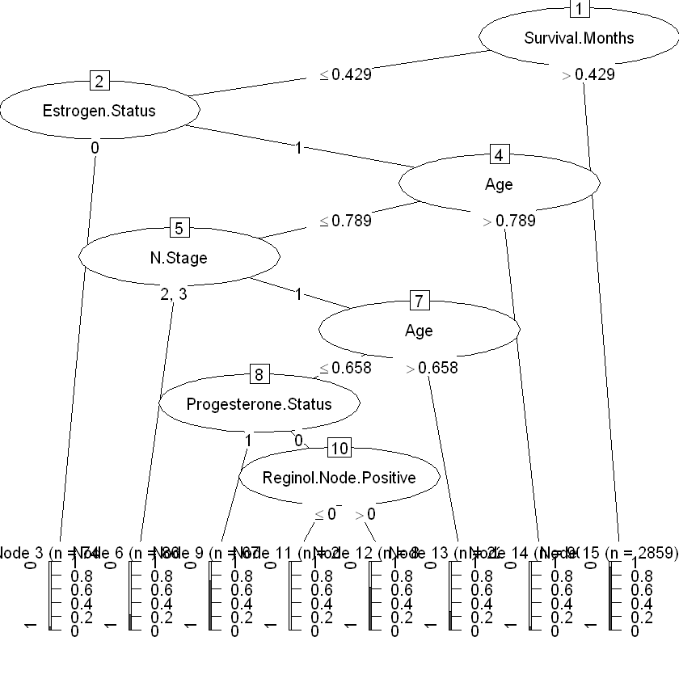

```r
# Plot the decision tree
plot(c45party)
```

```r
#Evaluate the model:
#install.packages("caret")
#install.packages('e1071', dependencies=TRUE)
library(e1071)
library(caret)

co_resultsu <- confusionMatrix(resultsn)
print(co_resultsu)
sensitivity(as.table(co_resultsu))
specificity(as.table(co_resultsu))
precision(as.table(co_resultsu))
accsn <- co_resultsu$overall["Accuracy"]
accsn
```

```
Confusion Matrix and Statistics


testPredsn   0   1
         0  57  16
         1  64 665

               Accuracy : 0.9002
                 95% CI : (0.8774, 0.9201)
    No Information Rate : 0.8491
    P-Value [Acc > NIR] : 1.332e-05

                  Kappa : 0.5348

 Mcnemar's Test P-Value : 1.482e-07

            Sensitivity : 0.47107
            Specificity : 0.97651
         Pos Pred Value : 0.78082
         Neg Pred Value : 0.91221
             Prevalence : 0.15087
         Detection Rate : 0.07107
   Detection Prevalence : 0.09102
      Balanced Accuracy : 0.72379

       'Positive' Class : 0
```

0.471074380165289

0.976505139500734

0.780821917808219

**Accuracy:** 0.900249376558603

# Tree 7 60% training and 40% testing using information gain

```r
# Split the dataset into 60% training and 40% testing subsets
indfod <- sample(1:nrow(dataset), size = floor(0.6 * nrow(dataset)), replace = FALSE)
trainDataa <- dataset[indfod,]
testDataa <- dataset[-indfod,]
```

```r
#tree 7 using information gain
# Using ID3 with rpart
dataset.iID3<- rpart(myFormula, data = trainDataa, method = "class", parms = list(split = "information"))
print(dataset.iID3)  # Display cp table for pruning
```

```
n= 2406

node), split, n, loss, yval, (yprob)
      * denotes terminal node

 1) root 2406 372 1 (0.15461347 0.84538653)
   2) Survival.Months< 0.4333333 283  82 0 (0.71024735 0.28975265)
     4) Age>=0.8026316 72   2 0 (0.97222222 0.02777778) *
     5) Age< 0.8026316 211  80 0 (0.62085308 0.37914692)
      10) X6th.Stage=2,4,5 122  27 0 (0.77868852 0.22131148) *
      11) X6th.Stage=1,3 89  36 1 (0.40449438 0.59550562)
        22) Marital.Status=2,3,4,5 39  17 0 (0.56410256 0.43589744)
          44) Regional.Node.Examined< 0.2372881 23   6 0 (0.73913043 0.26086957) *
          45) Regional.Node.Examined>=0.2372881 16   5 1 (0.31250000 0.68750000) *
        23) Marital.Status=1 50  14 1 (0.28000000 0.72000000) *
   3) Survival.Months>=0.4333333 2123 171 1 (0.08054640 0.91945360) *
```

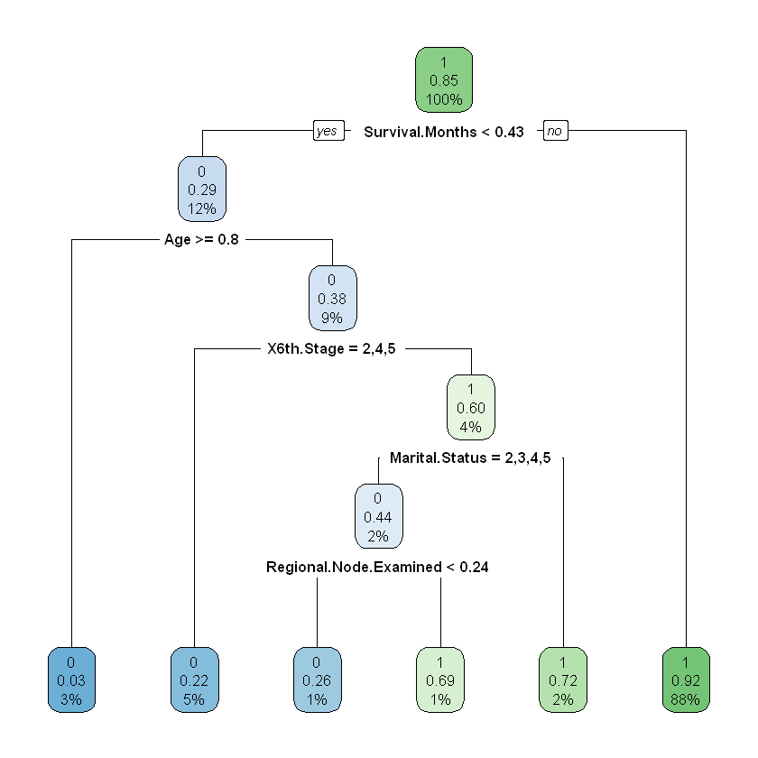

```r
# Plot the decision tree
rpart.plot(dataset.iID3)
```

```r
# Make predictions on the test set
testPredecy<- predict(dataset.iID3, newdata = testDataa, type = "class")
resultddy<- table(testPredecy, testDataa$Status)
```

```r
#Evaluate the model:
#install.packages("caret")
#install.packages('e1071', dependencies=TRUE)
library(e1071)
library(caret)

coresulty <- confusionMatrix(resultddy)
print(coresulty)
sensitivity(as.table(coresulty))
specificity(as.table(coresulty))
precision(as.table(coresulty))
accury<- coresulty$overall["Accuracy"]
accury
```

```
Confusion Matrix and Statistics


testPredecy    0    1
          0  113   24
          1  127 1340

               Accuracy : 0.9059
                 95% CI : (0.8905, 0.9197)
    No Information Rate : 0.8504
    P-Value [Acc > NIR] : 2.592e-11

                  Kappa : 0.5506

 Mcnemar's Test P-Value : < 2.2e-16

            Sensitivity : 0.47083
            Specificity : 0.98240
         Pos Pred Value : 0.82482
         Neg Pred Value : 0.91343
             Prevalence : 0.14963
         Detection Rate : 0.07045
   Detection Prevalence : 0.08541
      Balanced Accuracy : 0.72662

       'Positive' Class : 0
```

0.470833333333333

0.982404692082111

0.824817518248175

**Accuracy:** 0.905860349127182

For the Predictions , they are made on the test set using the trained decision tree. we calculated confusion matrix, sensitivity, specificity, precision, and overall accuracy . And the accuracy was high(90.58%) which indicates that a significant portion of the predictions made by the model match the actual outcomes in the test dataset.

# Tree 8 60% training and 40% testing using gini index

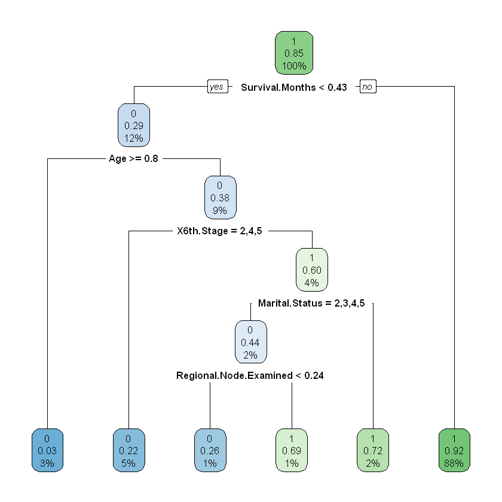

```r
#tree 8 using gini index
# Using CART with rpart
datasetcart. <- rpart(myFormula, data = trainDataa, method = "class", parms = list(split = "gini"))

# Plot the decision tree
library(rpart.plot)
rpart.plot(datasetcart.)
```

```r
#result

testPredcse<- predict(datasetcart., newdata = testDataa, type = "class")
resultcse <- table(testPredcse, testDataa$Status)
```

```r
#Evaluate the model:
co_resultcge <- confusionMatrix(resultcse)
print(co_resultcge)
sensitivity(as.table(co_resultcge))
specificity(as.table(co_resultcge))
precision(as.table(co_resultcge))
acccue<- co_resultcge$overall["Accuracy"]
acccue
```

```
Confusion Matrix and Statistics


testPredcse    0    1
          0  113   24
          1  127 1340

               Accuracy : 0.9059
                 95% CI : (0.8905, 0.9197)
    No Information Rate : 0.8504
    P-Value [Acc > NIR] : 2.592e-11

                  Kappa : 0.5506

 Mcnemar's Test P-Value : < 2.2e-16

            Sensitivity : 0.47083
            Specificity : 0.98240
         Pos Pred Value : 0.82482
         Neg Pred Value : 0.91343
             Prevalence : 0.14963
         Detection Rate : 0.07045
   Detection Prevalence : 0.08541
      Balanced Accuracy : 0.72662

       'Positive' Class : 0
```

0.470833333333333

0.982404692082111

0.824817518248175

**Accuracy:** 0.905860349127182

The following is a 40% testing and 60% Training gini index created where the classification label is known (pre-classified) for each record. Next, the algorithm systematically assigns each record to one of two subsets on the some basis whether ( Survival.Month <0.43) or not . The object is to attain an homogeneous set of labels in each partition This partitioning (splitting) is then applied to each of the new partitions. The process continues until no more useful splits can be found. The goal is to build a tree that distinguishes among the classes. For visualization the tree In this case, the tree is built using the variables Age, X6TH.Stage, marital.status ,Reginol.Node.examined, Survival.Monthsto know the status (0 dead, 1 alive). Survival months has minimum Gini index so it's the root.

For the Predictions , they are made on the test set using the trained decision tree. we calculated confusion matrix, sensitivity, specificity, precision, and overall accuracy . And the accuracy was high(90.58%) which indicates that a significant portion of the predictions made by the model match the actual outcomes in the test dataset as well as the other measurements.

# Tree 9 60% training and 40% testing using gain ratio

```r
#tree 9 using gain ratio
# Install and load the C50 package if not already installed
# install.packages("C50")
library(C50)
library(partykit)
library(party)
# Using C4.5 (C5.0) with C50
datasetc45. <- C5.0(myFormula, data = trainDataa)

# Print the tree rules
summary(datasetc45.)
```

```
Call:
C5.0.formula(formula = myFormula, data = trainDataa)


C5.0 [Release 2.07 GPL Edition]  	Sun Dec  3 00:20:41 2023
-------------------------------

Class specified by attribute `outcome'

Read 2406 cases (16 attributes) from undefined.data

Decision tree:

Survival.Months > 0.4285714: 1 (2123/171)
Survival.Months <= 0.4285714:
:...Age > 0.7894737: 0 (72/2)
    Age <= 0.7894737:
    :...Estrogen.Status = 0: 0 (51/4)
        Estrogen.Status = 1:
        :...Race = 2: 0 (21/2)
            Race in {1,3}:
            :...N.Stage = 3: 0 (30/7)
                N.Stage in {1,2}:
                :...Marital.Status in {1,4,5}: 1 (90/30)
                    Marital.Status in {2,3}: 0 (19/7)


Evaluation on training data (2406 cases):

	    Decision Tree
	  ----------------
	  Size      Errors

	     7  223( 9.3%)   <<


	   (a)   (b)    <-classified as
	  ----  ----
	   171   201    (a): class 0
	    22  2012    (b): class 1


	Attribute usage:

	100.00%	Survival.Months
	 11.76%	Age
	  8.77%	Estrogen.Status
	  6.65%	Race
	  5.78%	N.Stage
	  4.53%	Marital.Status


Time: 0.0 secs
```

```r
# Make predictions on the test set
testPredsni <- predict(datasetc45., newdata = testDataa)
resultsni<- table(testPredsni, testDataa$Status)
c45party. <- as.party(datasetc45.)
```

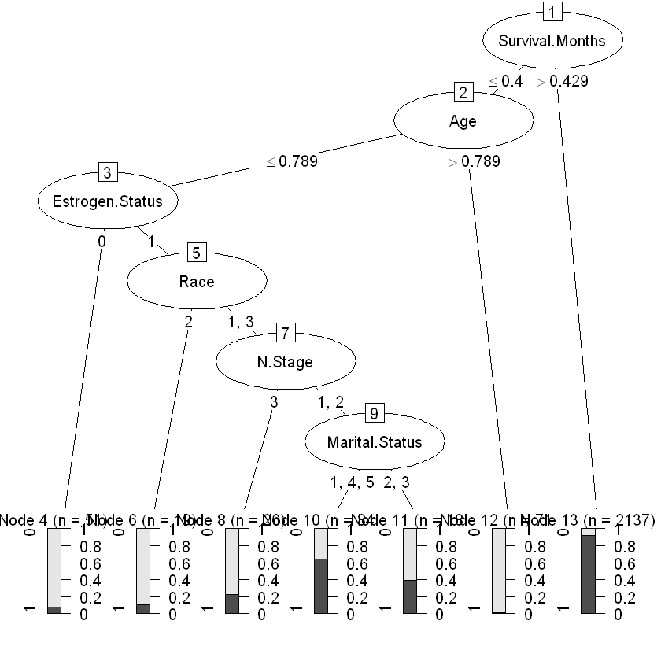

```r
# Plot the decision tree
plot(c45party.)
```

```r
#Evaluate the model:
#install.packages("caret")
#install.packages('e1071', dependencies=TRUE)
library(e1071)
library(caret)
co_resultsui <- confusionMatrix(resultsni)
print(co_resultsui)
sensitivity(as.table(co_resultsui))
specificity(as.table(co_resultsui))
precision(as.table(co_resultsui))
accsni <- co_resultsui$overall["Accuracy"]
accsni
```

```
Confusion Matrix and Statistics


testPredsni    0    1
          0  106   21
          1  134 1343

               Accuracy : 0.9034
                 95% CI : (0.8878, 0.9174)
    No Information Rate : 0.8504
    P-Value [Acc > NIR] : 2.07e-10

                  Kappa : 0.5289

 Mcnemar's Test P-Value : < 2.2e-16

            Sensitivity : 0.44167
            Specificity : 0.98460
         Pos Pred Value : 0.83465
         Neg Pred Value : 0.90928
             Prevalence : 0.14963
         Detection Rate : 0.06608
   Detection Prevalence : 0.07918
      Balanced Accuracy : 0.71314

       'Positive' Class : 0
```

0.441666666666667

0.984604105571848

0.834645669291339

**Accuracy:** 0.903366583541147

In summary, the three partitions (0.7 , 0.3 and 0.6 , 0.4 and 0.8 , 0.2) and the three attributes selection (IG, IG ratio, gini index) lead to similar results , such as all of them have high accuracy above(88% to 90.6%) and other measurements have similar results. This is a positive sign indicating that the model's performance is consistent and not overly dependent on specific choices. Information Gain, Information Gain Ratio, and Gini Index algorithms lead to similar results, it indicates that, these metrics are providing comparable insights into the dataset. consistency across different partitions and attribute selection methods is a positive signal, it's advisable to perform thorough evaluation, including testing on a separate dataset, to ensure the model's reliability and generalization capabilities.

# Clustring

Clustering is unsupervised learning so there is no class label, it is the task of dividing the unlabeled data or data points into different clusters such that similar data points fall in the same cluster than those which differ from the others. In simple words, the aim of the clustering process is to segregate groups with similar traits and assign them into clusters. in this project we used the K-means algorithm, it is a centroid-based clustering algorithm. it works randomly selecting K objects as the centroids of K clusters. Then, it assigns the other objects to the nearest cluster to them by measuring the distance between the centroid and each object. Consequently, updates the clusters and compute the new centroids, then repeats until no significant change of clusters occurs. For the approach to work, numerical data and prior knowledge of the number of clusters K are required, K-Means works well with our dataset because we converted every entry to a numeric value in the stage of preprocessing. K-Means clustering was applied with the assistance of the the R packages and packages listed below: factoextra package: Extract and Visualize the Results of Multivariate Data Analyses. cluster package: provides methods for Cluster analysis. NbClust package: provides 30 indexes for determining the optimal number of clusters in data set and offers the best clustering scheme from different results. set.seed(): Create reproducible results kmeans(): Clusters data based on similarity. fviz_cluster(): Visualize clustering results. silhouette(): Find the average for each and all clusters. fviz_silhouette(): Visualize the silhouette information. fviz_nbclust(): Determining the optimal number of clusters.

We will experiment with the following three values of k: (3,4,5). We will compute the average silhouette ,total within-cluster sum of square and the BCubed metrics (precision and recall) for each K.

# Clustr of size=3

this number was chosen after applying the silhouette method which shows that 3 is the optimal number for clustring This code applies the k-means clustering algorithm on the dataset, and then evaluates the clustering results using various metrics, including silhouette analysis and BCubed metrics.The BCubed metrics provide an evaluation of the clustering results by comparing them to ground truth label, assuming they are available in the 'datawithcl' dataset.

here we load the necessary librarys, removing the class label and take copy of the old dataset

```r
install.packages("cluster")
install.packages("Hmisc")
install.packages("factoextra")
install.packages("NbClust")
library(Hmisc)
library(factoextra)
library(NbClust)
library(cluster)

datawithcl<-dataset #dataset with the class label) # dataset with a class label
dataset <- dataset[, -which(names(dataset) == "Status")] #creates a copy of the dataset called datawithcl with the class label and then removes the class label column from the original dataset
str(dataset)
```

```
  There is a binary version available but the source version is later:
        binary source needs_compilation
cluster  2.1.5  2.1.6              TRUE

  Binaries will be installed
```

```
'data.frame':	4010 obs. of  15 variables:
 $ Age                   : num  0.974 0.5 0.711 0.711 0.421 ...
 $ Race                  : Factor w/ 3 levels "1","2","3": 1 1 1 1 1 1 1 1 1 1 ...
 $ Marital.Status        : Factor w/ 5 levels "1","2","3","4",..: 1 1 2 1 1 4 1 1 2 1 ...
 $ T.Stage               : Factor w/ 4 levels "1","2","3","4": 1 2 3 1 2 1 1 2 4 4 ...
 $ N.Stage               : Factor w/ 3 levels "1","2","3": 1 2 3 1 1 1 1 1 3 3 ...
 $ X6th.Stage            : Factor w/ 5 levels "1","2","3","4",..: 1 2 5 1 3 1 1 3 5 5 ...
 $ differentiate         : Factor w/ 4 levels "1","2","3","4": 3 2 2 3 3 2 1 2 3 1 ...
 $ Grade                 : Factor w/ 4 levels "1","2","3","4": 3 2 2 3 3 2 1 2 3 1 ...
 $ A.Stage               : Factor w/ 2 levels "0","1": 1 1 1 1 1 1 1 1 1 2 ...
 $ Tumor.Size            : num  0.0227 0.2576 0.4697 0.1288 0.303 ...
 $ Estrogen.Status       : Factor w/ 2 levels "0","1": 2 2 2 2 2 2 2 2 2 2 ...
 $ Progesterone.Status   : Factor w/ 2 levels "0","1": 2 2 2 2 2 2 2 2 2 2 ...
 $ Regional.Node.Examined: num  0.3898 0.2203 0.2203 0.0169 0.0339 ...
 $ Reginol.Node.Positive : num  0 0.1 0.15 0 0 0.025 0 0 0.425 0.275 ...
 $ Survival.Months       : num  0.552 0.571 0.695 0.781 0.457 ...
```

converting factors columns in the dataset to numeric format. The columns converted include 'Race,' 'Marital.Status,' 'T.Stage,' 'N.Stage,' 'X6th.Stage,' 'differentiate,' 'Grade,' 'A.Stage,' 'Estrogen.Status,' and 'Progesterone.Status' since we are applying k-means this is imoprtant step

```r
numeric_dataset = dataset
numeric_dataset$Race = as.numeric(as.character(dataset$Race))
numeric_dataset$Marital.Status = as.numeric(as.character(dataset$Marital.Status))
numeric_dataset$T.Stage = as.numeric(as.character(dataset$T.Stage))
numeric_dataset$N.Stage = as.numeric(as.character(dataset$N.Stage))
numeric_dataset$X6th.Stage = as.numeric(as.character(dataset$X6th.Stage))
numeric_dataset$differentiate = as.numeric(as.character(dataset$differentiate))
numeric_dataset$Grade = as.numeric(as.character(dataset$Grade))
numeric_dataset$A.Stage = as.numeric(as.character(dataset$A.Stage))
numeric_dataset$Estrogen.Status = as.numeric(as.character(dataset$Estrogen.Status))
numeric_dataset$Progesterone.Status = as.numeric(as.character(dataset$Progesterone.Status))
str(numeric_dataset)
```

```
'data.frame':	4010 obs. of  15 variables:
 $ Age                   : num  0.974 0.5 0.711 0.711 0.421 ...
 $ Race                  : num  1 1 1 1 1 1 1 1 1 1 ...
 $ Marital.Status        : num  1 1 2 1 1 4 1 1 2 1 ...
 $ T.Stage               : num  1 2 3 1 2 1 1 2 4 4 ...
 $ N.Stage               : num  1 2 3 1 1 1 1 1 3 3 ...
 $ X6th.Stage            : num  1 2 5 1 3 1 1 3 5 5 ...
 $ differentiate         : num  3 2 2 3 3 2 1 2 3 1 ...
 $ Grade                 : num  3 2 2 3 3 2 1 2 3 1 ...
 $ A.Stage               : num  0 0 0 0 0 0 0 0 0 1 ...
 $ Tumor.Size            : num  0.0227 0.2576 0.4697 0.1288 0.303 ...
 $ Estrogen.Status       : num  1 1 1 1 1 1 1 1 1 1 ...
 $ Progesterone.Status   : num  1 1 1 1 1 1 1 1 1 1 ...
 $ Regional.Node.Examined: num  0.3898 0.2203 0.2203 0.0169 0.0339 ...
 $ Reginol.Node.Positive : num  0 0.1 0.15 0 0 0.025 0 0 0.425 0.275 ...
 $ Survival.Months       : num  0.552 0.571 0.695 0.781 0.457 ...
```

appling the k-means clustering algorithm (kmeans function) to the preprocessed dataset with three clusters (centers = 3). The maximum number of iterations is set to 140, and the algorithm used is "Lloyd"which is an iterative method used to solve the k-means clustering problem. The algorithm minimizes the sum of squared distances between data points and the centroids (mean points) of their respective clusters. and The results are stored in the variable 'kmns'

```
K-means clustering with 3 clusters of sizes 529, 776, 2705

Cluster means:
        Age     Race Marital.Status  T.Stage  N.Stage X6th.Stage differentiate
1 0.6117799 1.230624       1.877127 2.425331 2.831758   4.886578      2.372401
2 0.6133681 1.279639       4.210052 1.717784 1.250000   1.993557      2.144330
3 0.6017901 1.217006       1.146765 1.676155 1.217745   1.941590      2.108688
     Grade    A.Stage Tumor.Size Estrogen.Status Progesterone.Status
1 2.372401 0.17202268  0.3220055       0.8695652           0.7429112
2 2.144330 0.00128866  0.2103932       0.9329897           0.8170103
3 2.108688 0.00000000  0.2060046       0.9463956           0.8458410
  Regional.Node.Examined Reginol.Node.Positive Survival.Months
1              0.3229631            0.32788280       0.5904762
2              0.2106631            0.04362113       0.6566274
3              0.2111532            0.03983364       0.6751589
```

[output cut: 513 more lines]

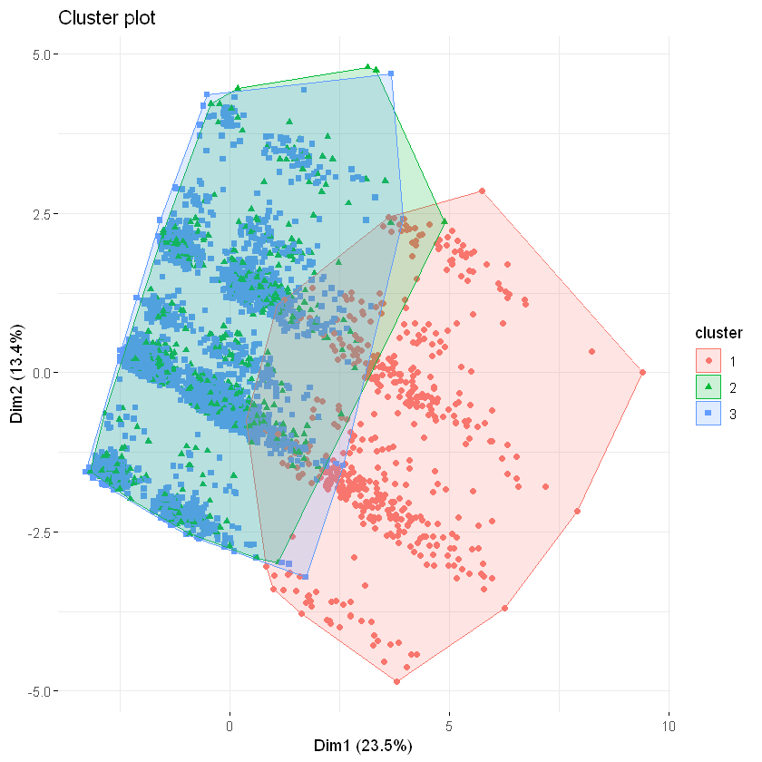

```r
kmns <- kmeans(numeric_dataset, 3, iter.max = 140 , algorithm="Lloyd", nstart=100)
kmns

#using the fviz_cluster function from the factoextra library to visualize the clustering results. The visualization includes points representing data, cluster centers, and ellipses around clusters.

library(factoextra)
fviz_cluster(kmns, data = numeric_dataset, geom = "point",
             show.clust.cent = FALSE, ellipse = TRUE,
             repel = TRUE, ggtheme = theme_minimal())
```

in the graph above you can see the clusters overlapping which could be because of the nature of the data since most real-world medical datasets have inherently overlapping information, which could be best explained by allowing one sample belong to more than one cluster. In our dataset we have specific information about breast cancer specially the tumor such as tumor size, N stage, 6th stage, T stage, differentiation and grade. These attributes can contribute to why the overlapping happened. you can notice the high density in cluster 3 as it has 2705 samples and the lowest density is cluster 1 as it has 529 samples. The within-cluster sum of squares measures the variability or dispersion of data points within each cluster. Cluster 1 has the lowest within-cluster sum of squares (2468.133), followed by cluster 2 (2558.139), and cluster 3 has the highest within-cluster sum of squares (7822.169). This suggests that data points within cluster 1 and cluster 2 are more tightly grouped or less dispersed compared to cluster 3, which has more variability within its data points. based on the within-cluster sum of squares, we can infer that clusters 1 and 2 have relatively more similar data points within each cluster, whereas cluster 3 has more diverse or dissimilar data points within the cluster.

# calculates silhouette scores for the clustering results using the

silhouette function and visualizes them using fviz_silhouette.

```
  cluster size ave.sil.width
1       1  529          0.30
2       2  776          0.38
3       3 2705          0.40
```

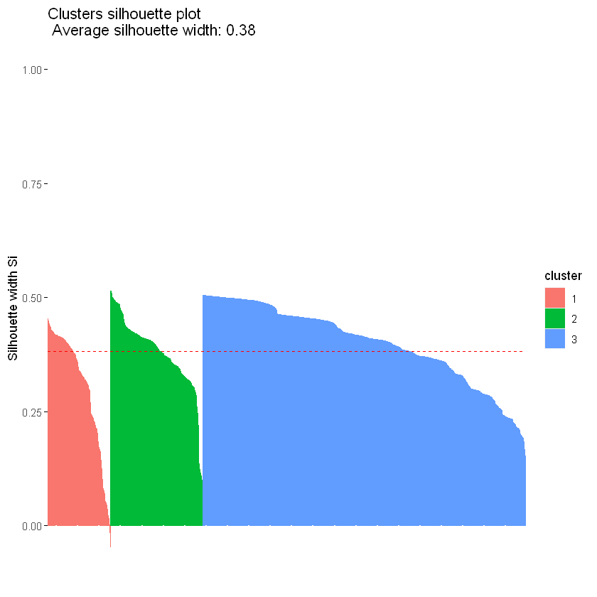

```r
#Cluster Validation
library(cluster)
#average for each cluster
avg_sil <- silhouette(kmns$cluster,dist(numeric_dataset))
fviz_silhouette(avg_sil)
```

the graph shows an average silhouette width of 0.38, it falls in the moderate range. It suggests that there is a reasonable level of separation and coherence among the clusters, but there may still be some overlap or ambiguity in the clustering results.

# calculates and prints the within-cluster sum of squares (WCSS), which

is a measure of the compactness of clusters. and print it

```r
# Calculate the WCSS
wcss <- sum(kmns$withinss)

# Print the WCSS
print(wcss)
```

```
[1] 12848.44
```

the WCSS value of 12848.44 suggests that there is a relatively high amount of variation within the clusters as a whole. This indicates that the data points within the clusters are not tightly packed around their respective centroids, and there may be significant overlap or uncertainty in the assignment of data points to clusters.

# defines a function 'calculate_bcubed_metrics' to compute BCubed

precision and recall. The function takes cluster assignments and ground truth labels(Status) as input and returns precision and recall. Then, it calculates and prints BCubed precision and recall for the clustering results.

```r
#BCubed Metrics
cluster_assignments <- kmns$cluster
ground_truth_labels <- datawithcl$Status

calculate_bcubed_metrics <- function(cluster_assignments, ground_truth_labels) {
  precision_sum <- recall_sum <- 0

  for (i in seq_along(cluster_assignments)) {
    same_category_same_cluster <- sum(ground_truth_labels[cluster_assignments == cluster_assignments[i]] == ground_truth_labels[i])
    total_same_cluster <- sum(cluster_assignments == cluster_assignments[i])
    total_same_category <- sum(ground_truth_labels == ground_truth_labels[i])

    precision_sum <- precision_sum + same_category_same_cluster / total_same_cluster
    recall_sum <- recall_sum + same_category_same_cluster / total_same_category
  }

  precision <- precision_sum / length(cluster_assignments)
  recall <- recall_sum / length(cluster_assignments)

  return(list(precision = precision, recall = recall))
}

metrics <- calculate_bcubed_metrics(cluster_assignments, ground_truth_labels)
precision <- metrics$precision
recall <- metrics$recall

cat("BCubed Precision:", precision)
cat("BCubed Recall:", recall)
```

```
BCubed Precision: 0.7567094BCubed Recall: 0.5227366BCubed Recall: 0.5227366
```

The precision score of 0.7567 suggests that, on average, around 75.67% of the data points assigned to a cluster are correctly assigned, reflecting the accuracy of the algorithm in clustering the data. The recall score of 0.5227 indicates that, on average, approximately 52.27% of the data points that should have been assigned to a cluster are indeed captured by the algorithm, showcasing its ability to identify relevant data points within each cluster. These results demonstrate a trade-off between precision and recall, where the algorithm achieves good precision but sacrifices some recall. From these results, we can conclude that the clustering algorithm has achieved relatively high precision (around 75.67%), indicating that the algorithm tends to assign data points correctly within each cluster. However, the recall value is moderate (around 52.27%), suggesting that the algorithm may have missed capturing a few portion of the similar data points within each cluster but still relatively good.